# QC-espresso

Quality control report for DIA proteomics data

Author

Guilherme Lanfredi

Published

November 3, 2026

Abstract

This report provides a structured quality control assessment of data-independent acquisition (DIA) proteomics experiments processed with DIA-NN. The analysis supports instrument performance monitoring, dataset validation, and longitudinal QC tracking. QC-espresso is an open-source workflow implemented in R and Quarto.

**NoteQC-espresso resources**

The source code, documentation, example data, and portable Windows release are available in the [QC-espresso GitHub repository](https://github.com/lanfredig/QC-espresso_DIA).

If you find QC-espresso useful in your research, please cite the associated publication: [*QC-espresso: Brewing quality in proteomics*](https://doi.org/10.64898/2026.10.29.762921).

**WarningRuns excluded by global confidence filtering**

**3 acquisition run(s) were completely removed after decoy exclusion and application of `PG.Q.Value <= 0.01`.**

**Affected run(s):** 17, 18, 19

These runs are absent from downstream QC outputs because no entries remained after the initial confidence filter.

# 1. Identification performance

**NoteIdentification depth**

This section reports **identification depth per run** at the **precursor**, **modified peptide sequence**, and **protein‑group** levels.

These levels capture complementary aspects of identification performance: precursor counts distinguish charge‑ and modification‑specific precursor forms, modified peptide sequences retain sequence and modification information, and protein groups summarize identification at the inference level used for downstream analyses.

Horizontal reference lines indicate the **mean identification count across runs** (blue dotted), the **maximum identification count observed in a single run** (red dotted), and the **total number of distinct identifiers across the complete filtered dataset** (purple solid) for each level. The dataset-wide total counts each identifier only once, even when it occurs in multiple runs. These descriptive references should be interpreted together with chromatographic, intensity, and completeness QC metrics.

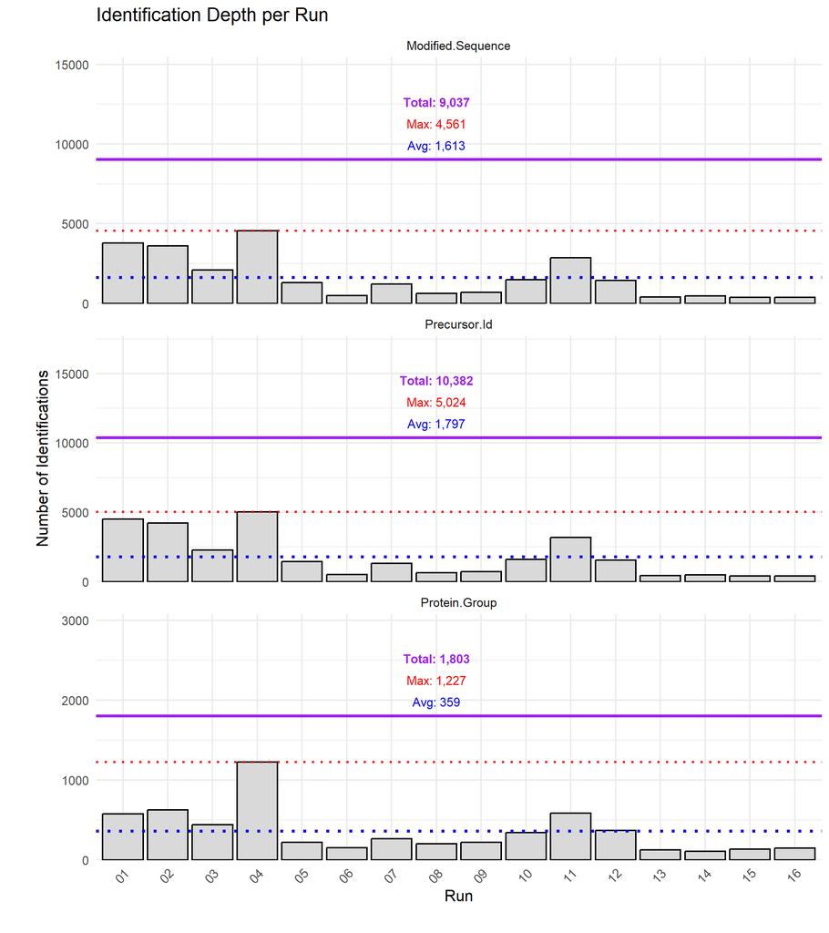

Identification Depth per Run

Precursors, peptides, and protein groups

| Run | Precursors | Peptides | Protein.Groups |
| --- | --- | --- | --- |
| 01 | 4,519 | 3,785 | 577 |
| 02 | 4,214 | 3,604 | 627 |
| 03 | 2,276 | 2,098 | 442 |
| 04 | 5,024 | 4,561 | 1,227 |
| 05 | 1,457 | 1,310 | 221 |
| 06 | 520 | 497 | 153 |
| 07 | 1,314 | 1,216 | 264 |
| 08 | 654 | 618 | 201 |
| 09 | 722 | 694 | 222 |
| 10 | 1,609 | 1,487 | 342 |
| 11 | 3,191 | 2,860 | 584 |
| 12 | 1,548 | 1,444 | 371 |
| 13 | 424 | 408 | 124 |
| 14 | 479 | 455 | 110 |
| 15 | 400 | 380 | 135 |
| 16 | 397 | 386 | 150 |

TOTAL across all runs - Peptides: 9,037; Precursors: 10,382; Protein Groups: 1,803

# 2. Quantitative signal composition

**NoteRelative abundance and contaminant contribution**

This section summarizes the **relative composition of protein-group signal within each run**, calculated by summing positive `Precursor.Quantity` values for each original `Protein.Group`. FASTA-derived gene or accession labels are used for visualization without redistributing quantitative signal among individual accessions. The ten annotation labels with the highest total signal across the filtered dataset are displayed individually, while the remaining labels are grouped as **Others**.

Relative signal-composition profiles provide a concise assessment of sample composition and quantitative balance between runs. Consistent patterns may indicate stable sample preparation and instrument response, whereas pronounced shifts may reflect differences in sample loading, sample composition, preparation, acquisition, background contamination, or overall signal balance.

When protein groups containing recognized `CON_` or `cRAP-` accession prefixes and positive quantitative signal are available, an additional plot highlights signal associated with annotated contaminants, which may include keratins, proteolytic enzymes, and other common laboratory contaminants. The plot shows the **relative composition of contaminant signal within each run**, while the accompanying label reports the fraction of total run signal assigned to these recognized contaminants. If the recognized prefixes or positive contaminant signal are unavailable, the contaminant plot is omitted and an explanatory notice is displayed.

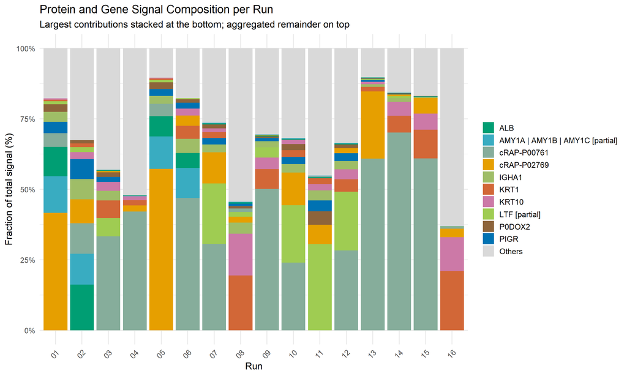

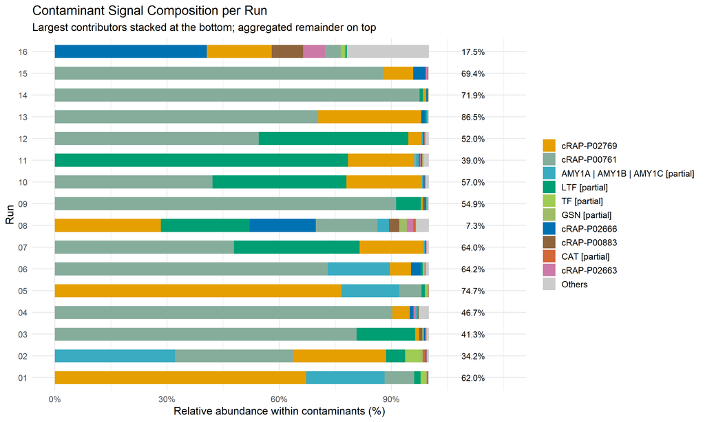

# 3. Sequence coverage

**NoteProtein sequence coverage**

This section summarizes **protein sequence coverage** based on exact matching of identified peptides to reference protein sequences.

Coverage reflects the fraction of amino acid positions supported by at least one mapped peptide. All occurrences of each unique peptide are considered, while overlapping peptide mappings do not result in duplicate counting of covered residues. The summary table reports the **top 100 reference proteins** ranked by sequence coverage, while the density plot provides an overview of the coverage distribution among proteins with positive sequence coverage.

The exported CSV file includes proteins with at least one covered amino acid position, together with their mapped peptide evidence. Proteins without mapped peptide evidence remain represented in the complete in-memory coverage table but are not included in the exported CSV. Sequence coverage complements identification depth by describing how extensively individual reference protein sequences are sampled rather than how many proteins are detected.

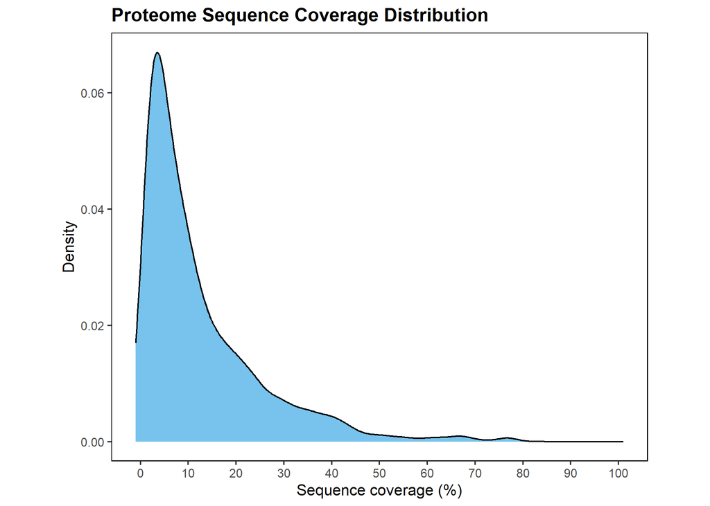

Protein Sequence Coverage Summary (Top 100)

Mapped peptide evidence for covered proteins is exported as CSV

| Accession | Protein Name | Length (aa) | Covered AA | Coverage (%) |
| --- | --- | --- | --- | --- |
| P0DTE7 | Alpha-amylase 1B | 511 | 395 | 77.3% |
| P0DTE8 | Alpha-amylase 1C | 511 | 395 | 77.3% |
| P0DUB6 | Alpha-amylase 1A | 511 | 395 | 77.3% |
| P02768 | Albumin | 609 | 466 | 76.5% |
| P02788 | Lactotransferrin | 710 | 543 | 76.5% |
| Q9UBC9 | Small proline-rich protein 3 | 169 | 127 | 75.1% |
| P62805 | Histone H4 | 103 | 74 | 71.8% |
| P62937 | Peptidyl-prolyl cis-trans isomerase A | 165 | 114 | 69.1% |
| P60174 | Triosephosphate isomerase | 249 | 171 | 68.7% |
| P01040 | Cystatin-A | 98 | 67 | 68.4% |
| P23528 | Cofilin-1 | 166 | 112 | 67.5% |
| A0A0A0MT89 | Immunoglobulin kappa joining 1 | 12 | 8 | 66.7% |
| P61604 | 10 kDa heat shock protein, mitochondrial | 102 | 68 | 66.7% |
| P12273 | Prolactin-inducible protein | 146 | 97 | 66.4% |
| P08727 | Keratin, type I cytoskeletal 19 | 400 | 265 | 66.2% |
| P07355 | Annexin A2 | 339 | 223 | 65.8% |
| P25311 | Zinc-alpha-2-glycoprotein | 298 | 191 | 64.1% |
| P06899 | Histone H2B type 1-J | 126 | 80 | 63.5% |
| P00558 | Phosphoglycerate kinase 1 | 417 | 263 | 63.1% |
| P62328 | Thymosin beta-4 | 44 | 27 | 61.4% |
| P23284 | Peptidyl-prolyl cis-trans isomerase B | 216 | 132 | 61.1% |
| P35908 | Keratin, type II cytoskeletal 2 epidermal | 639 | 388 | 60.7% |
| P07737 | Profilin-1 | 140 | 85 | 60.7% |
| P14618 | Pyruvate kinase PKM | 531 | 312 | 58.8% |
| P63173 | Large ribosomal subunit protein eL38 | 70 | 40 | 57.1% |
| P01009 | Alpha-1-antitrypsin | 418 | 237 | 56.7% |
| P04083 | Annexin A1 | 346 | 193 | 55.8% |
| P04264 | Keratin, type II cytoskeletal 1 | 644 | 354 | 55% |
| O00299 | Chloride intracellular channel protein 1 | 241 | 130 | 53.9% |
| P05109 | Protein S100-A8 | 93 | 50 | 53.8% |

[output cut: 70 more lines]

# 4. Peptide-level quality

**NotePeptide‑level metrics**

This section summarizes **peptide‑level quality metrics** across runs, including precursor **charge‑state distribution**, **peptide length**, and **missed tryptic cleavages**.

Charge‑state distributions are calculated from distinct combinations of run, precursor identifier, and precursor charge. Peptide length and missed‑cleavage metrics are calculated from distinct stripped peptide sequences within each run. Peptide length distributions include the median length per run, while digestion efficiency is assessed through the fraction of unique stripped peptide sequences containing at least one missed tryptic cleavage.

A missed cleavage is assigned when an internal lysine or arginine is not followed by proline, while a terminal lysine or arginine is not counted as a missed cleavage. Together, these metrics provide complementary information to identification counts by capturing variation in precursor charge, peptide length, and digestion performance that may not be evident at the protein‑group level.

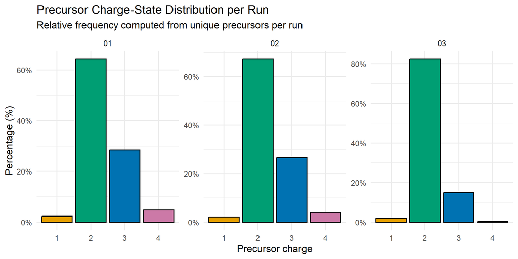

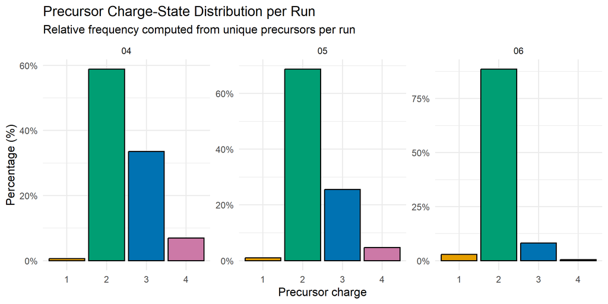

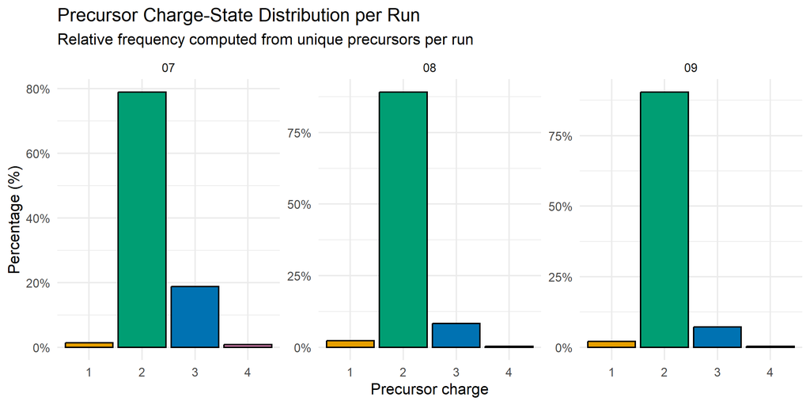

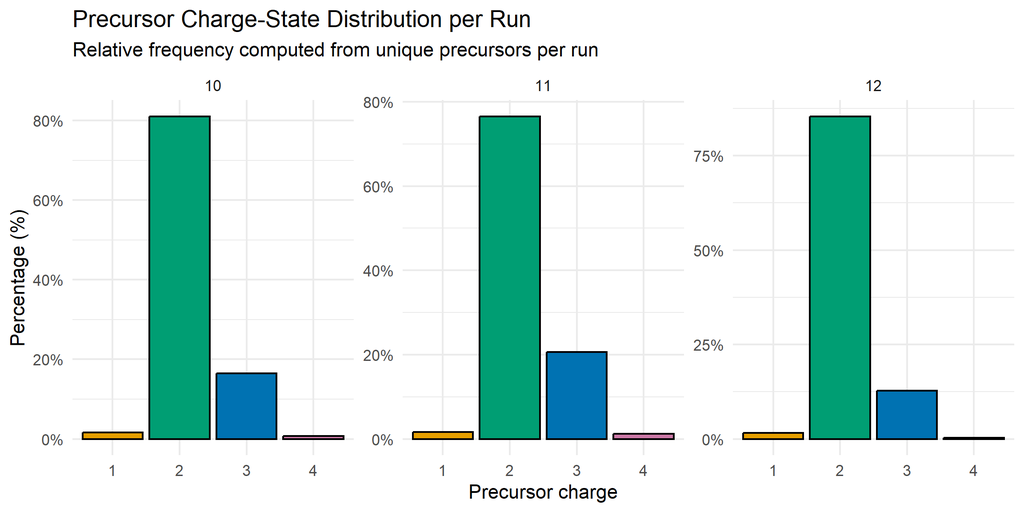

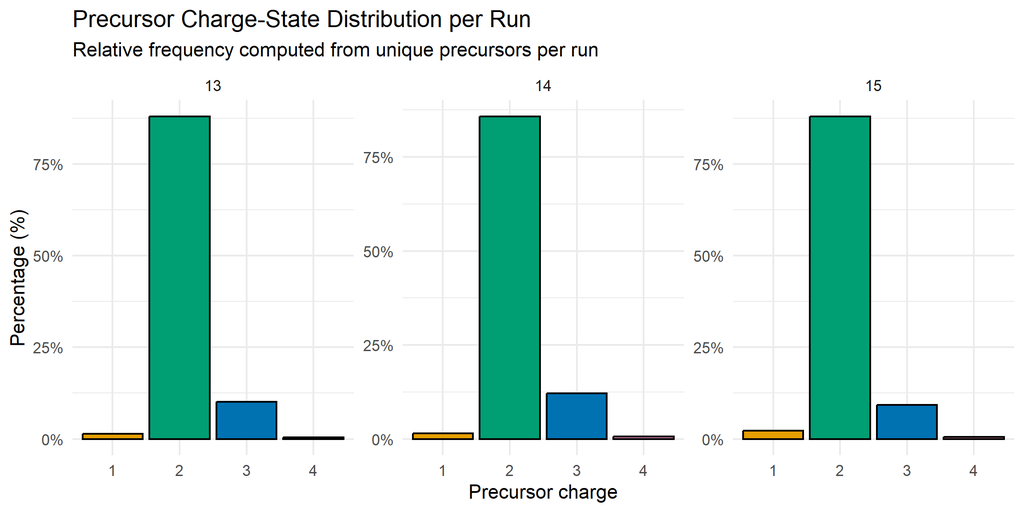

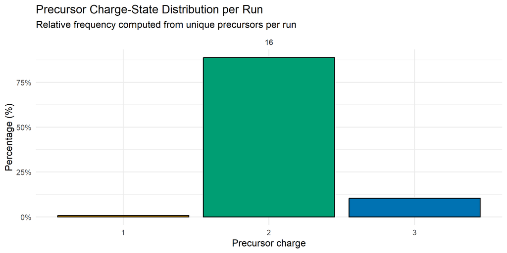

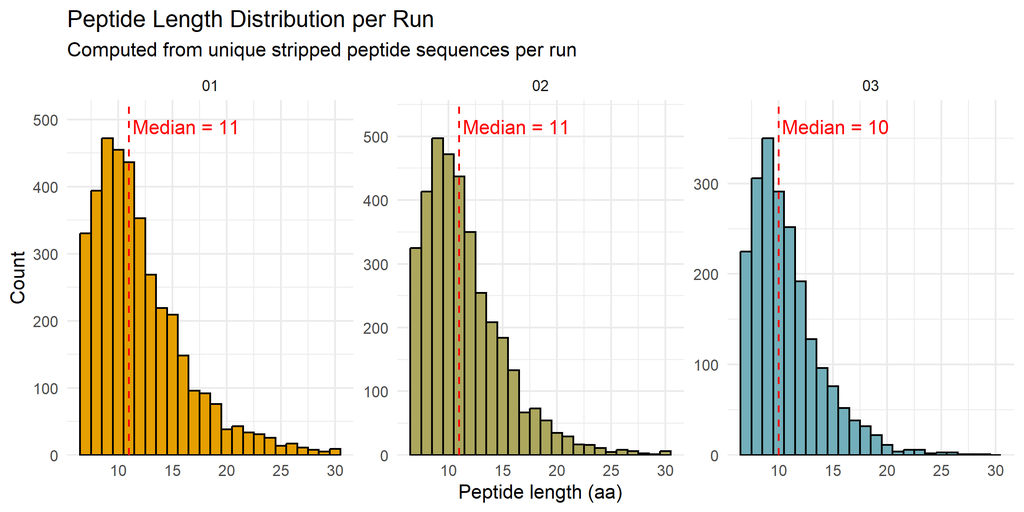

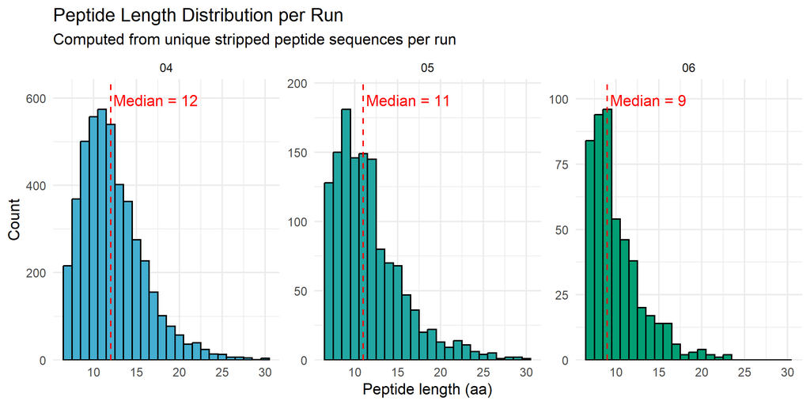

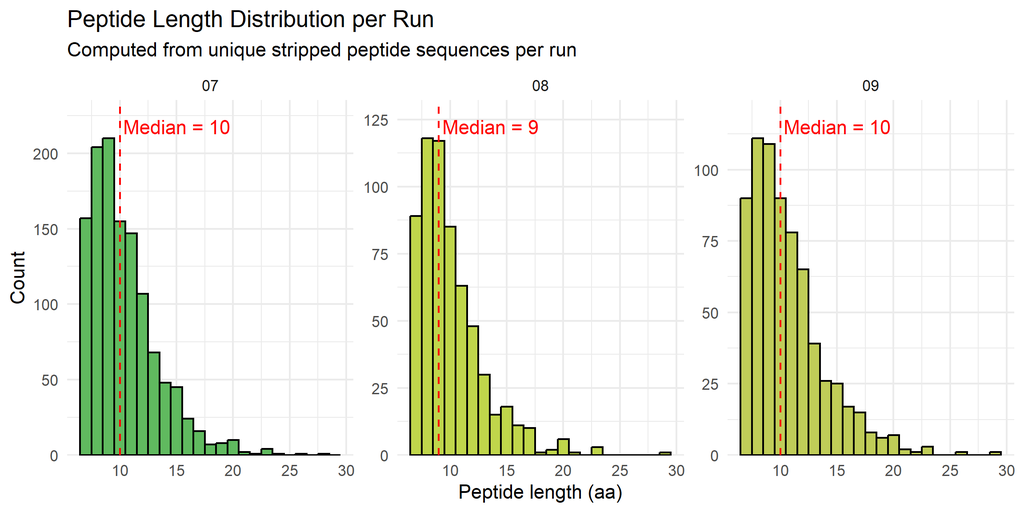

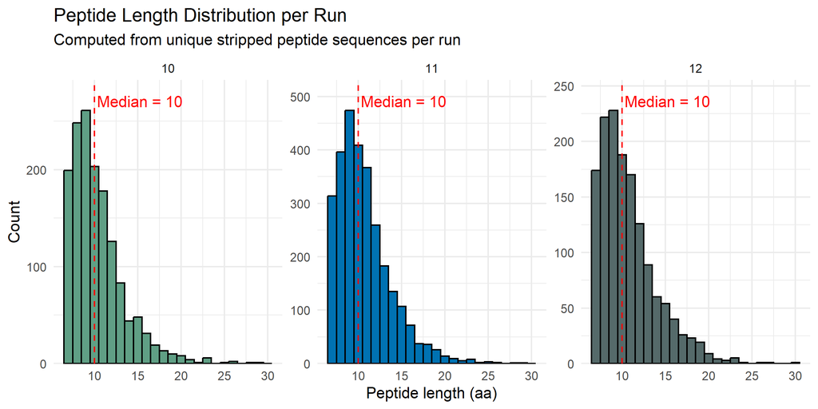

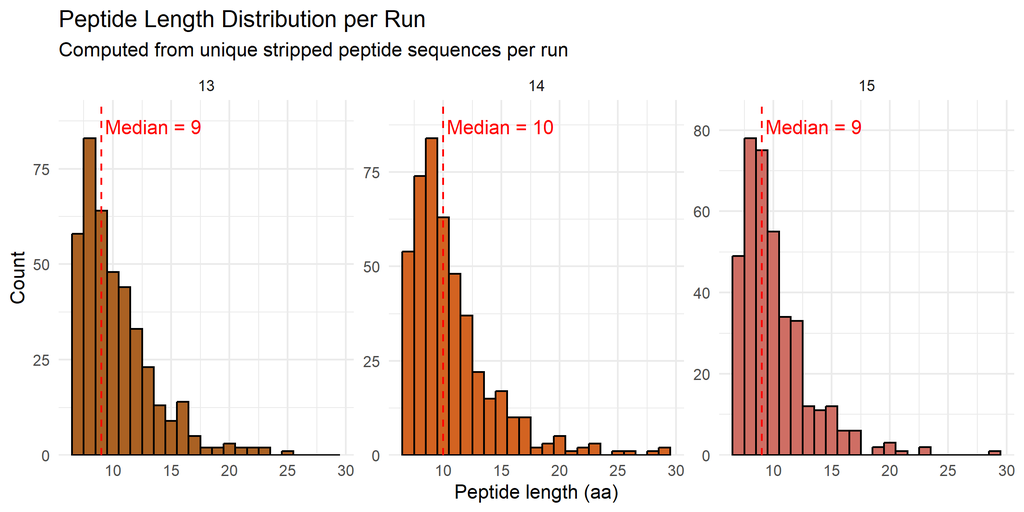

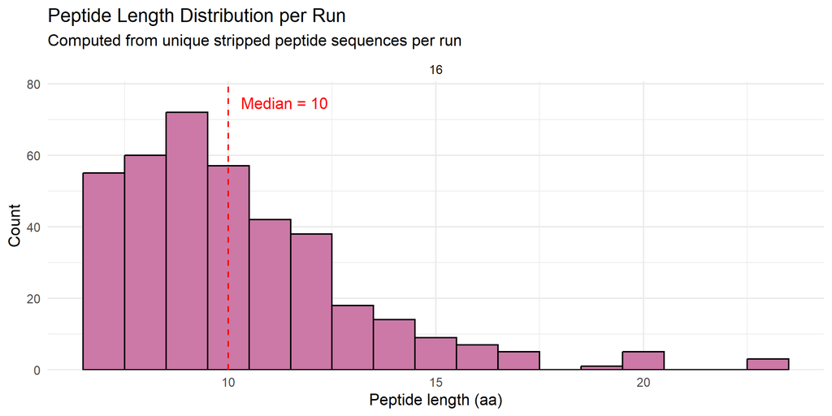

[1 more figures not shown]

# 5. Chromatographic performance

**NoteChromatography quality**

This section evaluates **chromatographic performance and retention‑time behavior** across runs using the distribution of retained DIA‑NN report entries over retention time, peak width metrics, and monitoring of trypsin autolysis precursors.

The distribution of retained report entries over retention time summarizes how quantitative precursor-level observations are distributed across the LC gradient, providing an overview of gradient utilization and run‑to‑run stability. Peak width metrics, including **full width at half maximum (FWHM)** and **peak base width**, are reported in seconds and characterize chromatographic peak width and separation performance. Median FWHM and peak base width values are indicated for each run.

Retention‑time reproducibility and quantitative signal stability are additionally assessed for three predefined **trypsin autolysis precursors**, which serve as internal process references for digestion, chromatography, and acquisition performance. These measurements may still be influenced by sample preparation, digestion efficiency, matrix composition, and signal availability. Together, the plots can reveal patterns consistent with gradient drift, peak broadening, altered chromatographic separation, or reduced run‑to‑run stability.

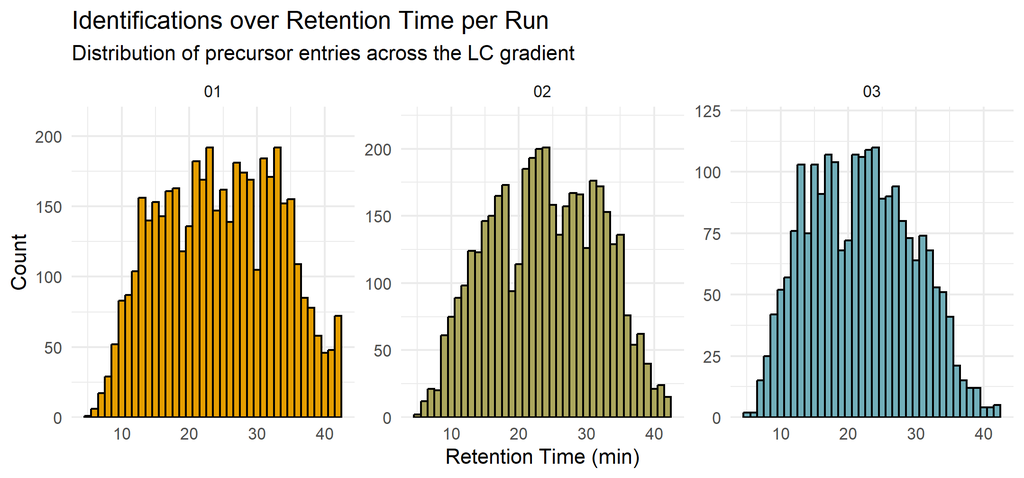

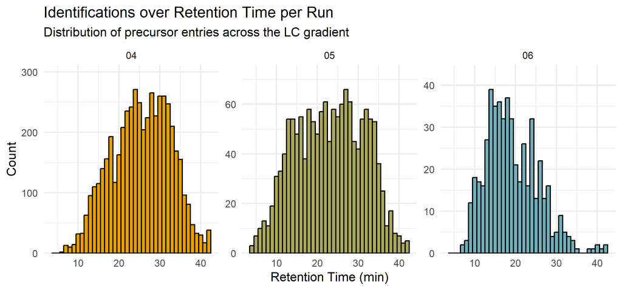

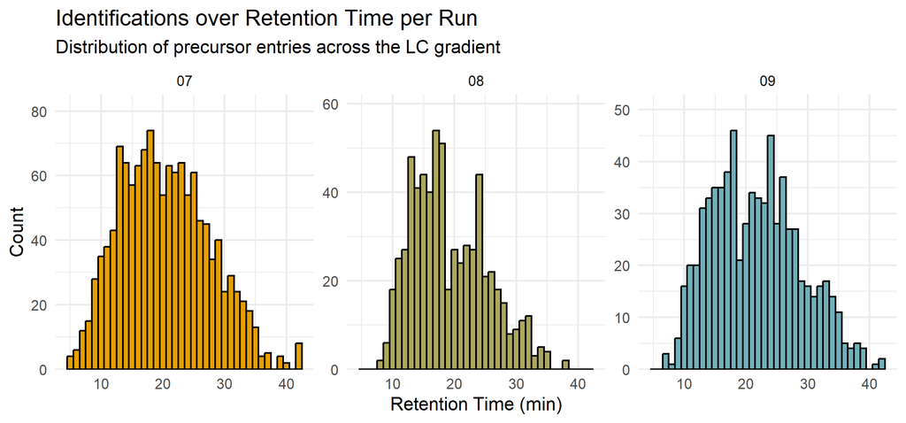

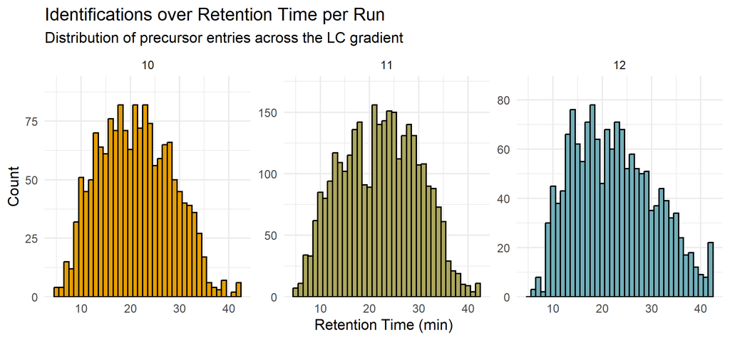

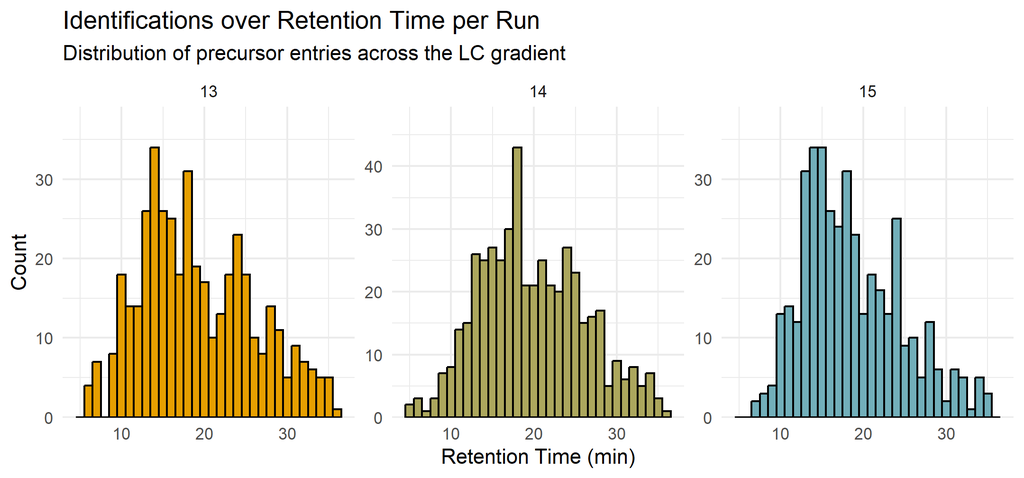

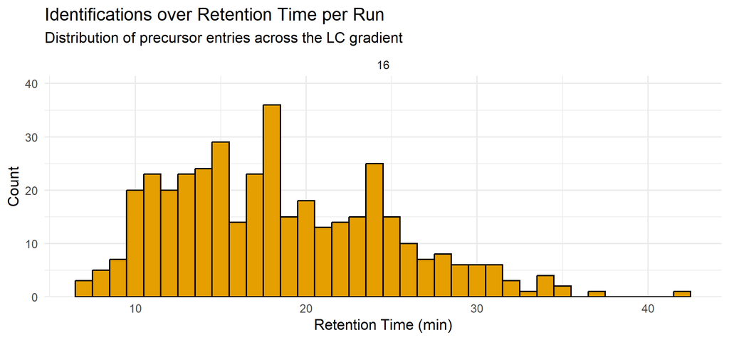

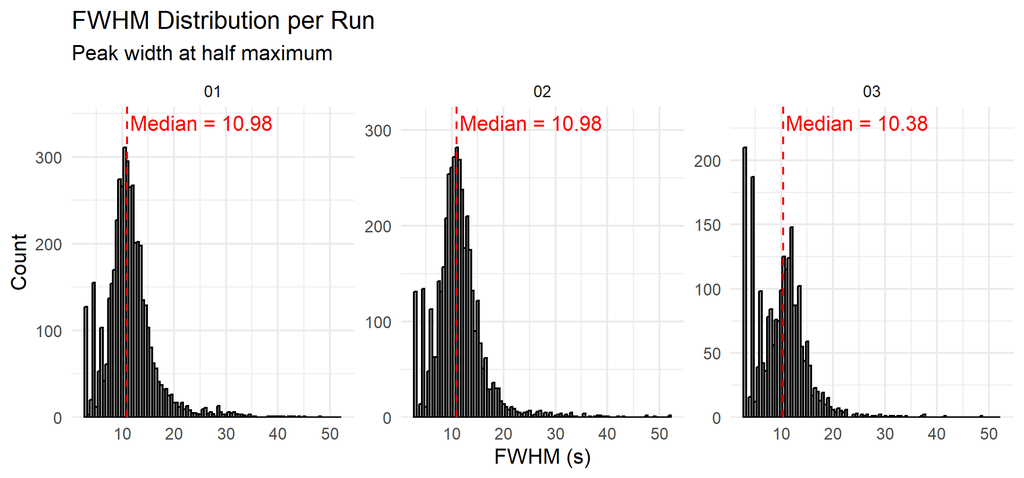

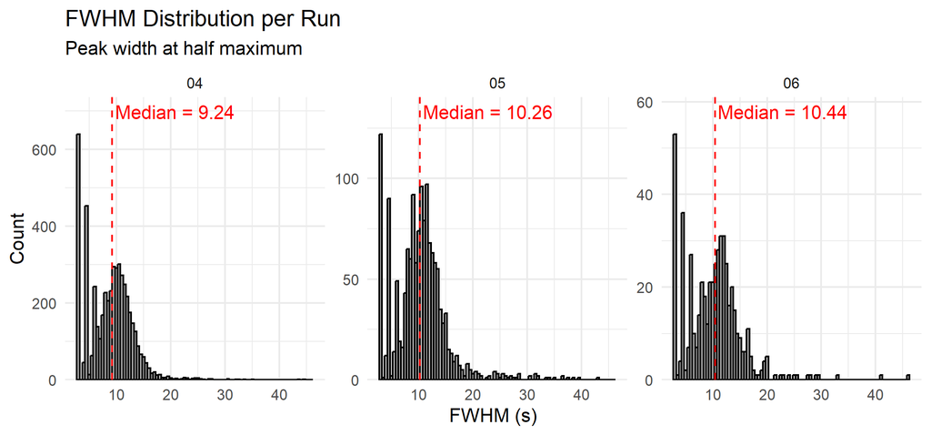

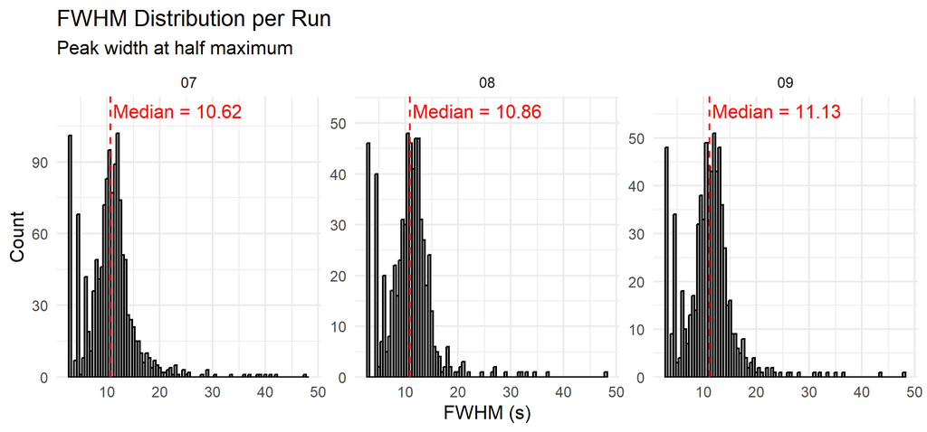

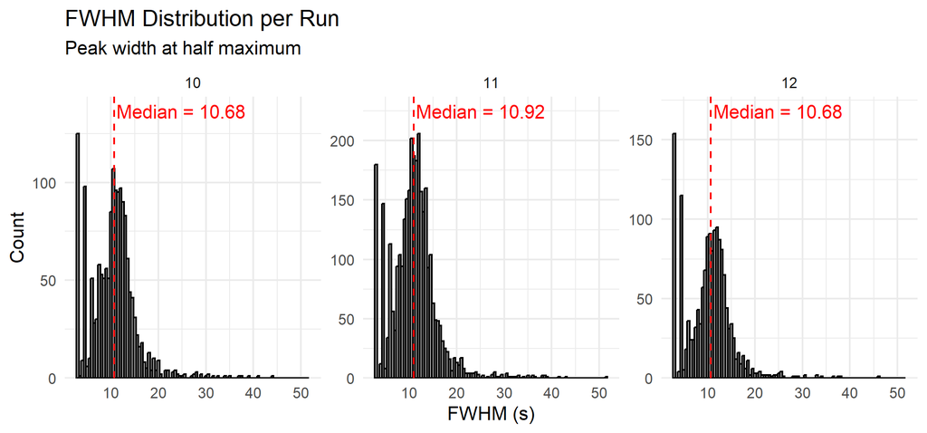

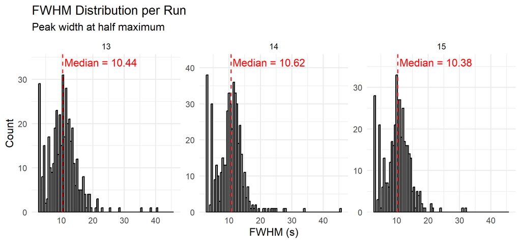

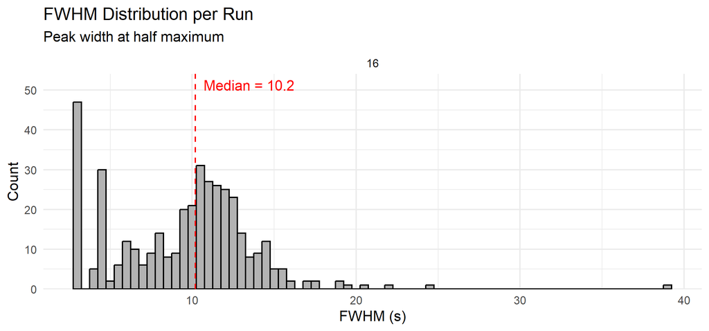

[8 more figures not shown]